# presentation slides

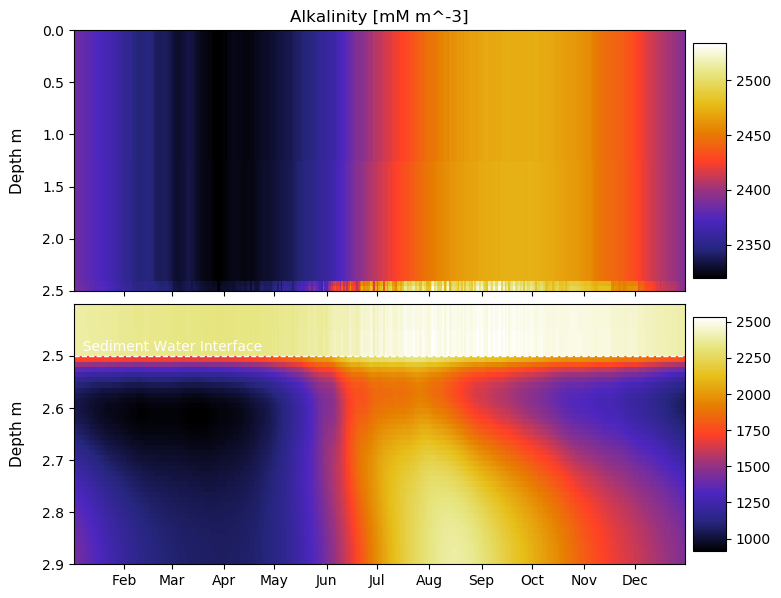

```python
import visualize2 as vs2
vs2.plot_fig(start_year=2010,stop_year=2011,name='B_C_Alk',title='Alkalinity',
              path='data/results/5_po75-25_di10e-9')
```

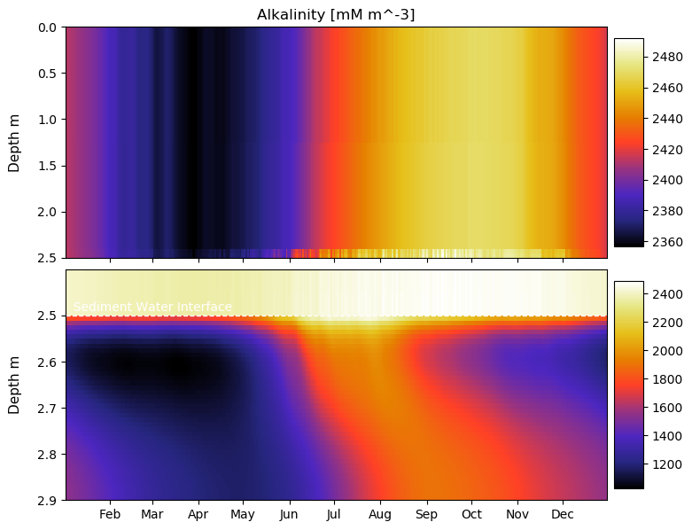

```python
vs2.plot_fig(start_year=2010,stop_year=2011,name='B_C_Alk',title='Alkalinity',
              path='data/tides')
```

## Carbon dioxide absorption drivers by seawater in the coastal area, the case of the Wadden Sea

pCO$_2$: In seawater and the atmosphere

Depends on mainly:

- temperature
- biological activities (production and degradation of organic matter)
- alkalinity? (since it determines the buffer capacity of seawater)

Two tasks of the Thesis:

1. Calculate alkalinity
2. Compare alkalinity influence on pCO2 with temperature and biological effects

## Alkalinity expressions

Total alkalinity is excess of $\lbrack\text{Na}^{+}\rbrack + 2\lbrack\text{Mg}^{2 +}\rbrack + 2\lbrack\text{Ca}^{2 +}\rbrack + \lbrack \text{K}^{+}\rbrack +$ … over $\lbrack\text{Cl}^{-}\rbrack + \lbrack\text{Br}^{-}\rbrack + \lbrack\text{NO}_{3}^{-}\rbrack + 2\text{SO}_{4}$ … , where all compound ions “can be regarded as ‘conservative’ in the sense that their concentrations are unaffected by changes in the pH, pressure, or temperature” Zeebe, Wolf-Gladrow (2001).

$\text{TA}_{\text{ec}} = \lbrack\text{Na}^{+}\rbrack + 2\lbrack\text{Mg}^{2 +}\rbrack + 2\lbrack\text{Ca}^{2 +}\rbrack + \lbrack \text{K}^{+}\rbrack + 2\lbrack\text{Sr}^{2 +}\rbrack + \text{TNH}_{3} - \lbrack\text{Cl}^{-}\rbrack - \lbrack\text{Br}^{-}\rbrack - \lbrack\text{NO}_{3}^{-}\rbrack - \text{TPO}_{4} - 2\text{TSO}_{4} - \text{THF} - \text{THNO}_{2}$ (Eq. 1)

, where $\text{TNH}_{3} = \lbrack\text{NH}_{3}\rbrack + \lbrack\text{NH}_{4}^{+}\rbrack$, $\text{TPO}_{4} = \lbrack\text{H}_{3}\text{PO}_{4}\rbrack + \lbrack \text{H}_{2}\text{PO}_{4}^{-}\rbrack + \lbrack\text{HPO}_{4}^{2 -}\rbrack + \lbrack\text{PO}_{4}^{3 -}\rbrack$, $\text{TSO}_{4} = \lbrack\text{SO}_{4}^{2 -}\rbrack + \lbrack\text{HSO}_{4}^{-}\rbrack$, $\text{THF} = \lbrack \text{F}^{-}\rbrack + \lbrack\text{HF}\rbrack$, and $\text{THNO}_{2} = \lbrack\text{NO}_{2}^{-}\rbrack + \lbrack\text{HNO}_{2}\rbrack$.